# Heart Disease Prediction

A. Nguyen, B. Waite

7/17/2019

#Introduction:

This study hopes to identify factors contributing to the development of heart disease in an observed population and to train a logistic regression model to predict whether future patients will develop heart disease given the same set of factors.

#Data:

The data used in this study were obtained from the archives of the University of California, Irvine and are available on the web at: https://archive.ics.uci.edu/ml/datasets/Heart+Disease.

A brief summary of the variables contained in the data is available in the table below. A more robust description of each variable is contained in Appendix A.

[output not shown]

|  | age | sex | cp | trestbps | chol | fbs | restecg | thalach | exang | oldpeak | slope | ca | thal | target |
| --- | --- | --- | --- | --- | --- | --- | --- | --- | --- | --- | --- | --- | --- | --- |
|  | Min. :29.00 | 0: 96 | 0:143 | Min. : 94.0 | Min. :126.0 | 0:258 | 0:147 | Min. : 71.0 | 0:204 | Min. :0.00 | 0: 21 | 0:175 | 0: 2 | 0:138 |
|  | 1st Qu.:47.50 | 1:207 | 1: 50 | 1st Qu.:120.0 | 1st Qu.:211.0 | 1: 45 | 1:152 | 1st Qu.:133.5 | 1: 99 | 1st Qu.:0.00 | 1:140 | 1: 65 | 1: 18 | 1:165 |
|  | Median :55.00 | NA | 2: 87 | Median :130.0 | Median :240.0 | NA | 2: 4 | Median :153.0 | NA | Median :0.80 | 2:142 | 2: 38 | 2:166 | NA |
|  | Mean :54.37 | NA | 3: 23 | Mean :131.6 | Mean :246.3 | NA | NA | Mean :149.6 | NA | Mean :1.04 | NA | 3: 20 | 3:117 | NA |
|  | 3rd Qu.:61.00 | NA | NA | 3rd Qu.:140.0 | 3rd Qu.:274.5 | NA | NA | 3rd Qu.:166.0 | NA | 3rd Qu.:1.60 | NA | 4: 5 | NA | NA |
|  | Max. :77.00 | NA | NA | Max. :200.0 | Max. :564.0 | NA | NA | Max. :202.0 | NA | Max. :6.20 | NA | NA | NA | NA |

Some interesting breakdowns / observations contained within the data:

- The age range in the data set is from 29 to 77 years old. Age distribution is normal.
- There are 303 total participants. 207 Male and 96 Female.
- Nearly balanced response samples: 138 no heart disease vs 165 with heart disease.
- General contingency tables of Sex by Target (diagnosed with cardiac disease) shows:
  - Proportion of female with heart disease is greater than proportion of male with heart disease

```
##     target   0   1 Sum
## sex
## 0           24  72  96
## 1          114  93 207
## Sum        138 165 303
```

```
##    target
## sex         0         1
##   0 0.1739130 0.4363636
##   1 0.8260870 0.5636364
```

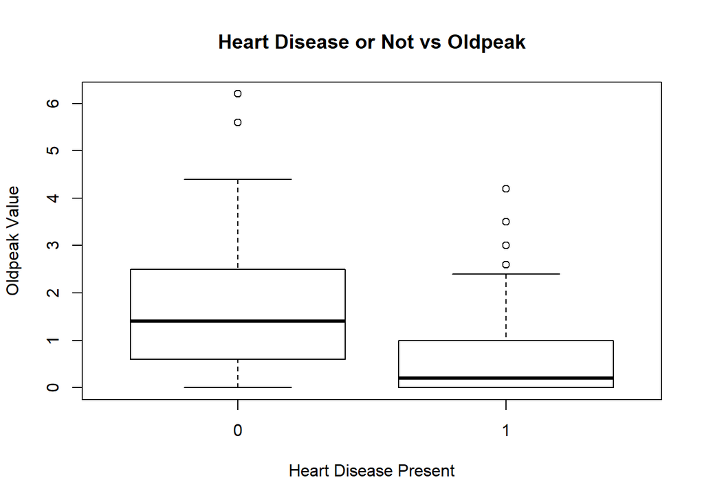

- There also appear to be some outliers in the oldpeak data set that you can see on the boxplot above and are present in the histogram that is right skewed. Log transforming the oldpeak variable does help with normality. We don’t know if this is required at this point, but is good to keep in mind and may help to improve our prediction model later.

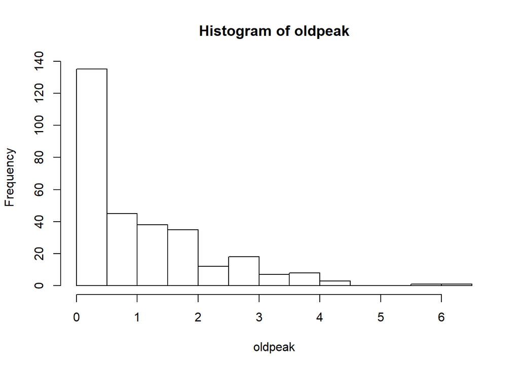

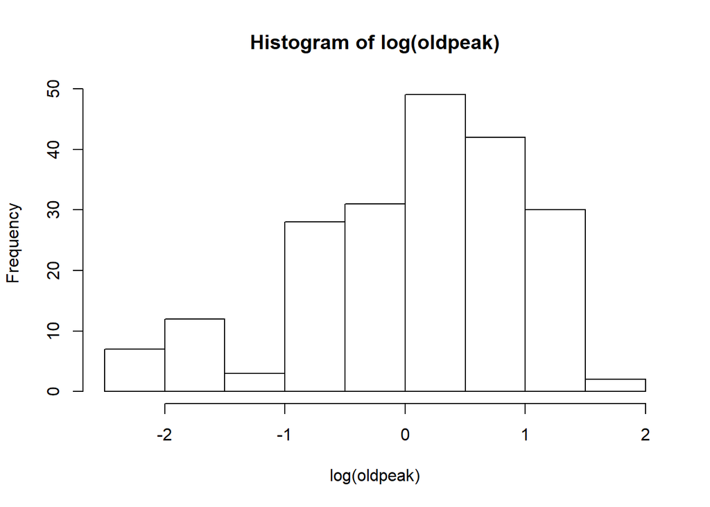

The maximum heart rate achieved during the stress test (thalach) also appears to be strongly correlated with the outcome of whether a patient will have heart disease or not.

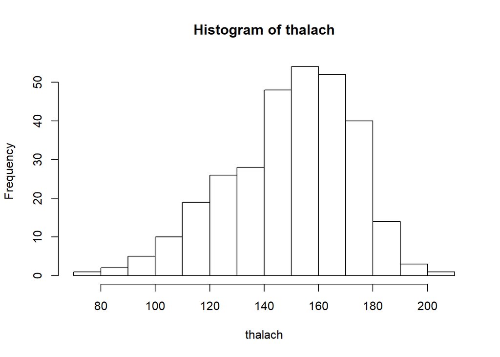

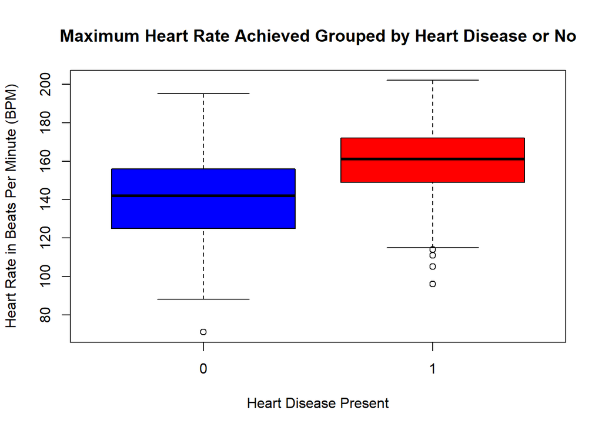

Visualizing the Relationships between Response and Categorical Predictors through Stacked Bargraphs

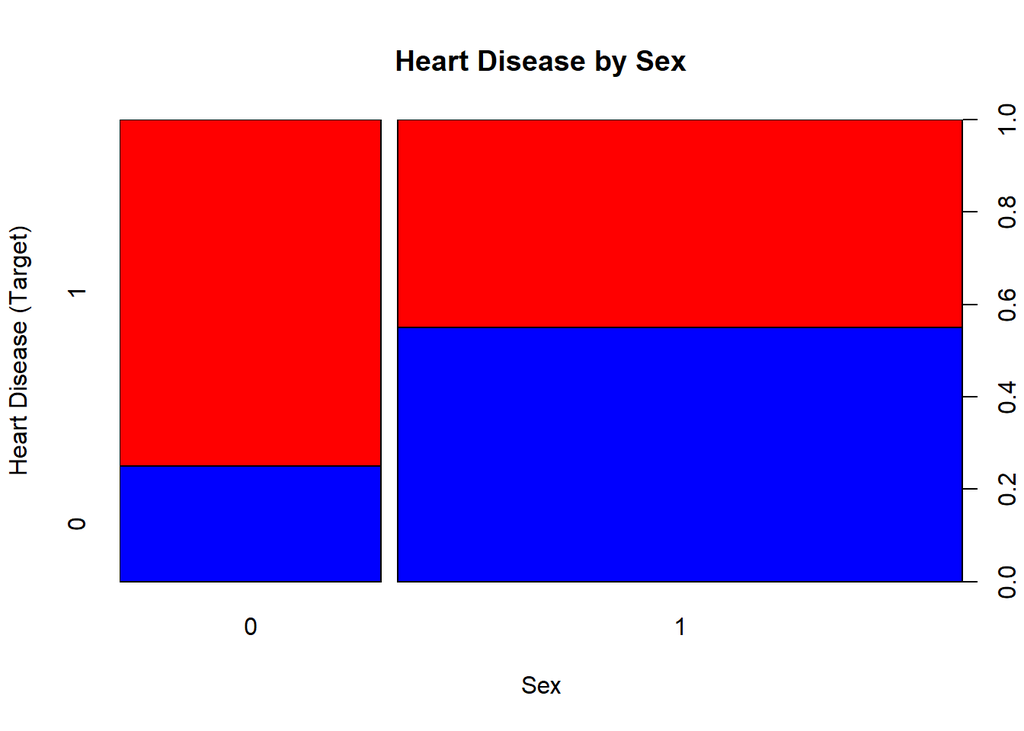

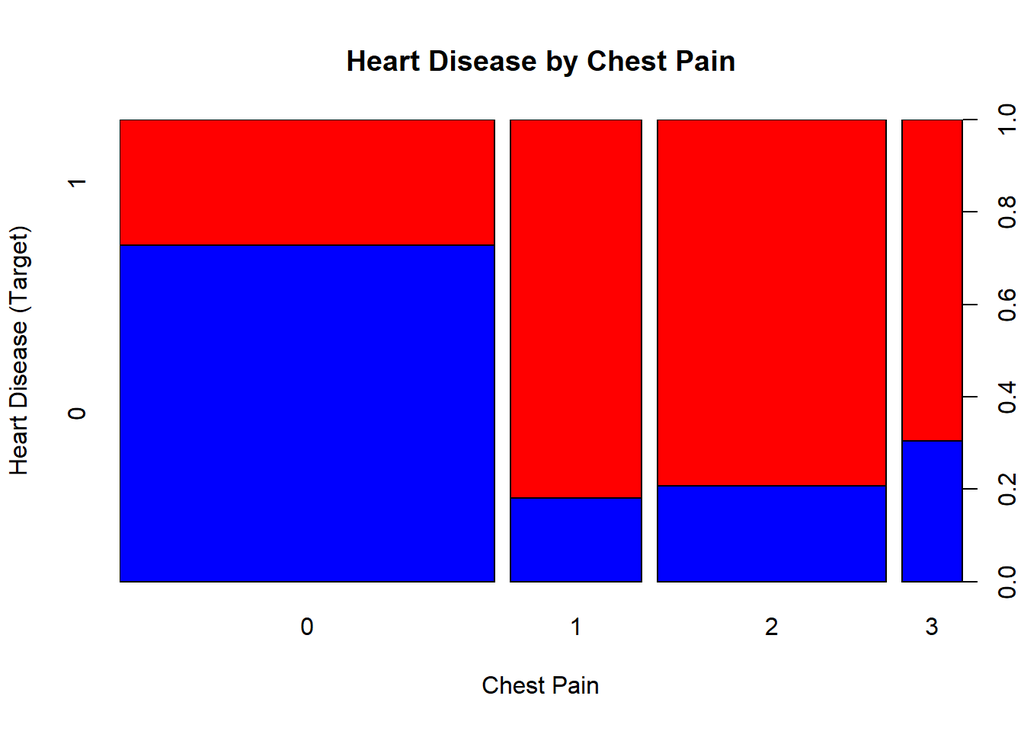

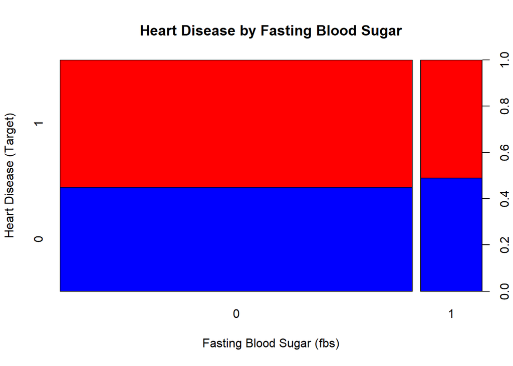

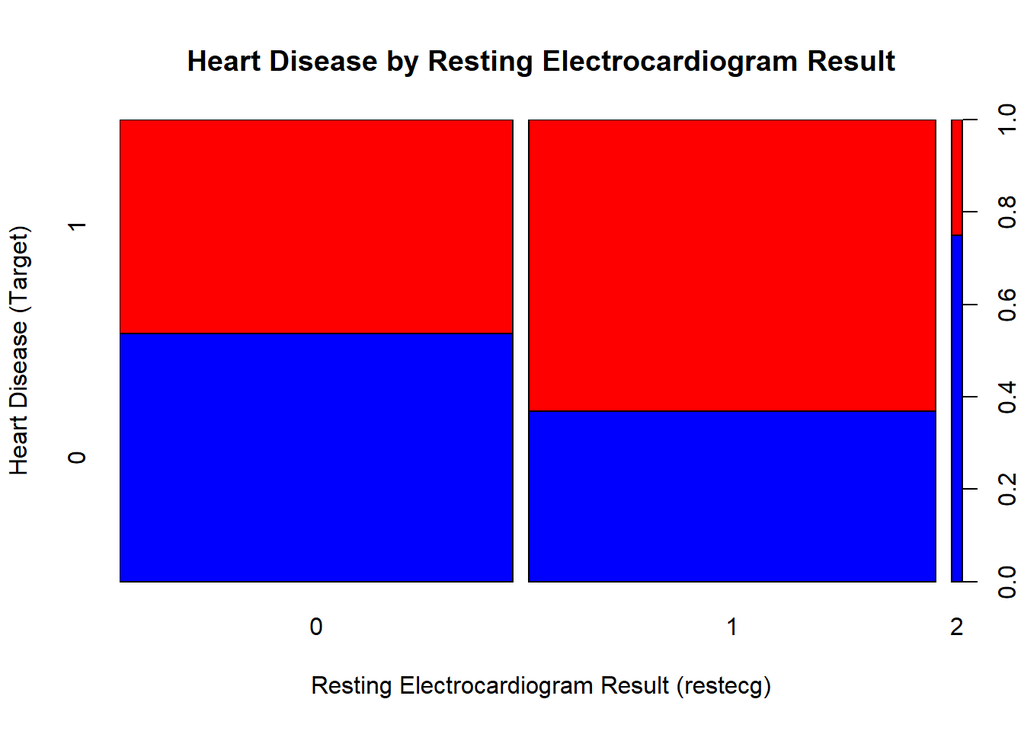

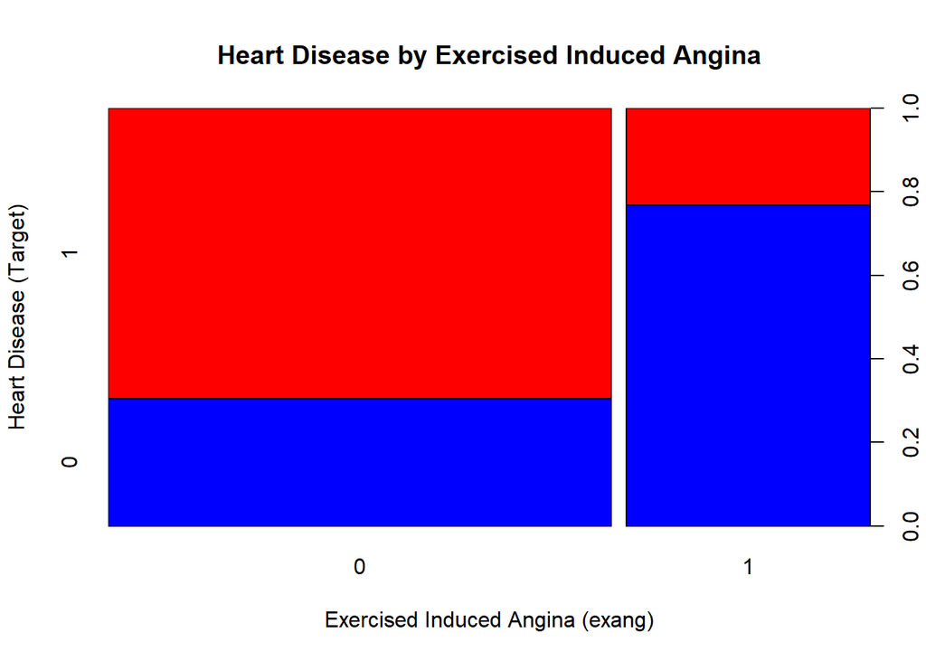

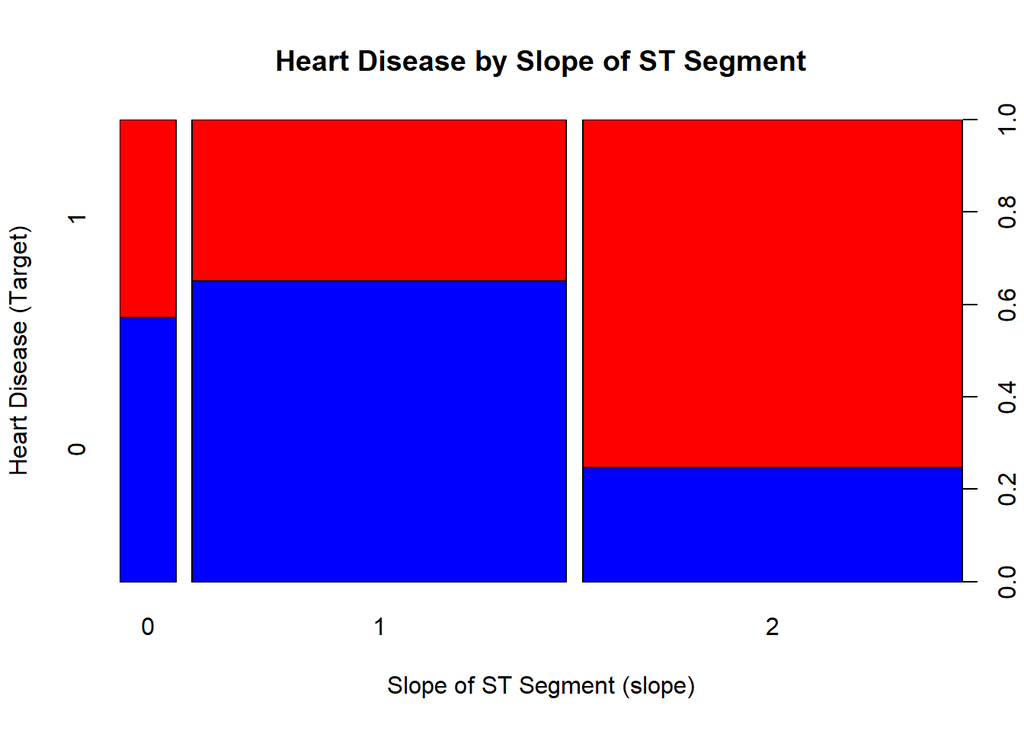

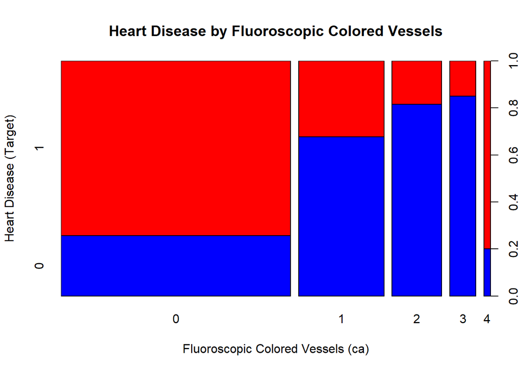

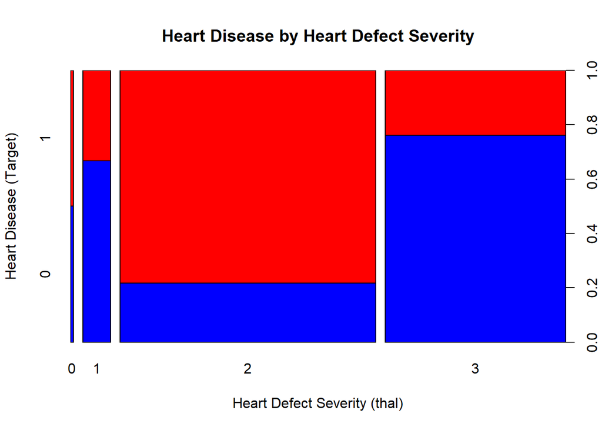

- Visualizations + additional contingency tables (Appendix B) show:
  - positive correlation between chest pain (*cp*) and heart disease (*target*)
  - possible negative correlation between exercise induced angina (*exang*) and heart disease (*target*)
  - negative correlation between fluoroscopic colored vessels (*ca*) and heart disease (*target*)
  - higher proportion of patients with defect level (*thal*) of 2 have heart disease while higher proportion of patients at other defect levels do not have heart disease [REQUIRES FURTHER INVESTIGATION]

Visualizing the Relationships between Response and Continuous Predictors through Boxplots

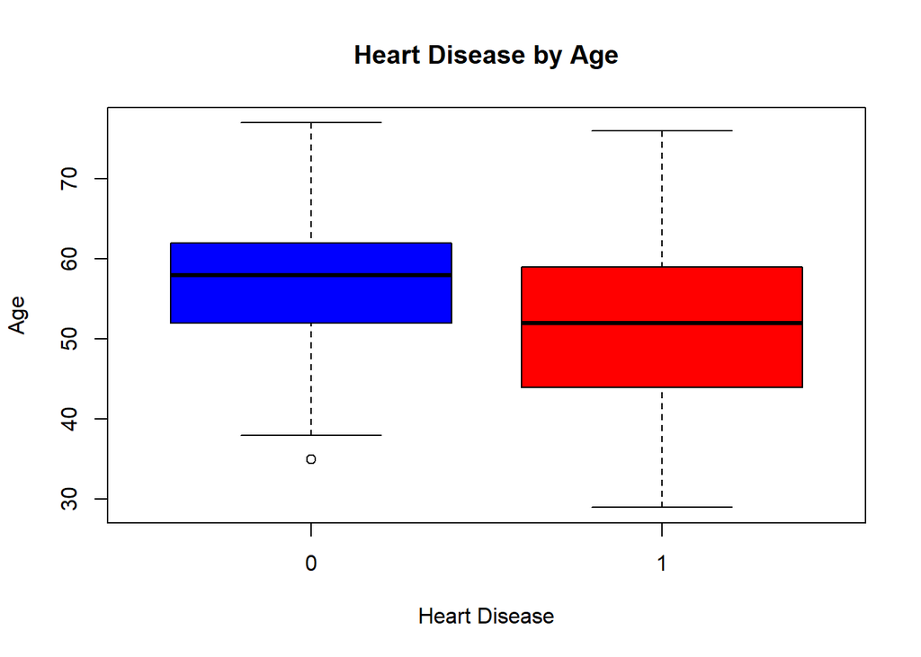

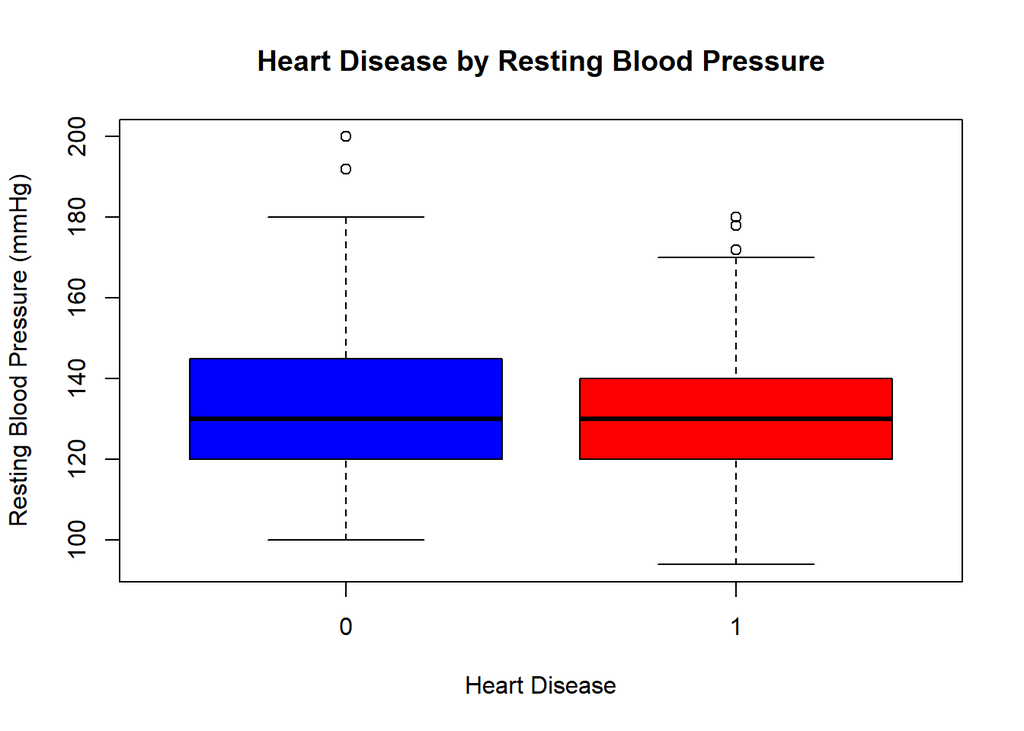

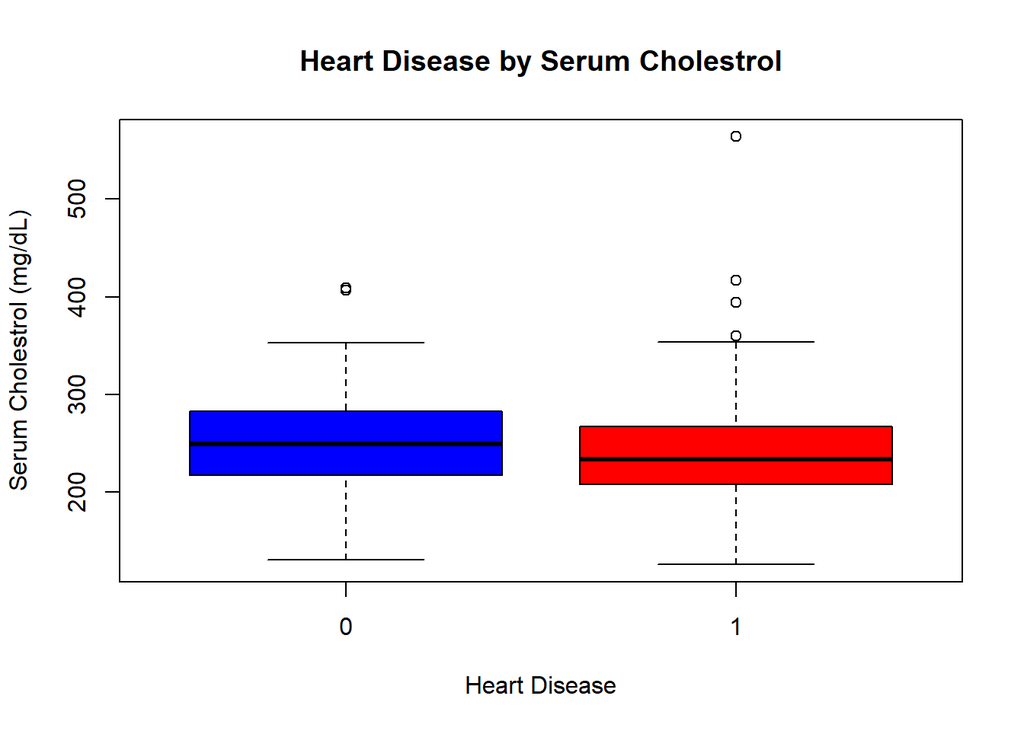

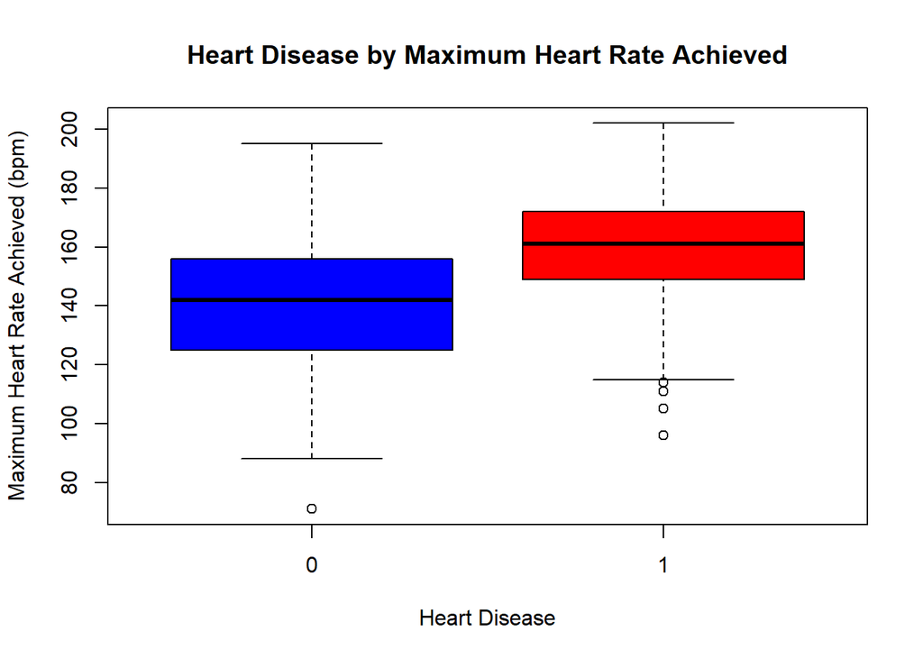

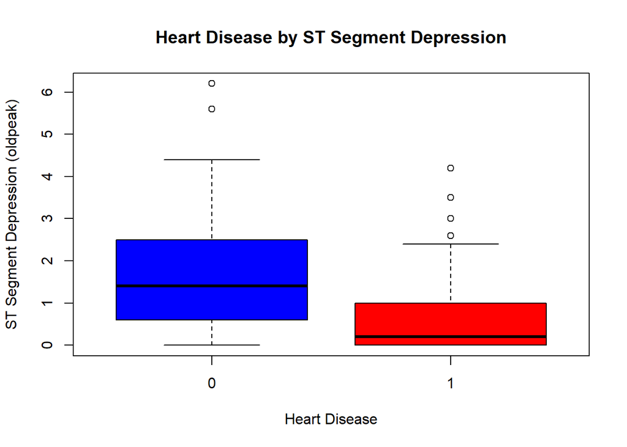

Visualize Correlation Patterns and Distributions of Continuous Variables

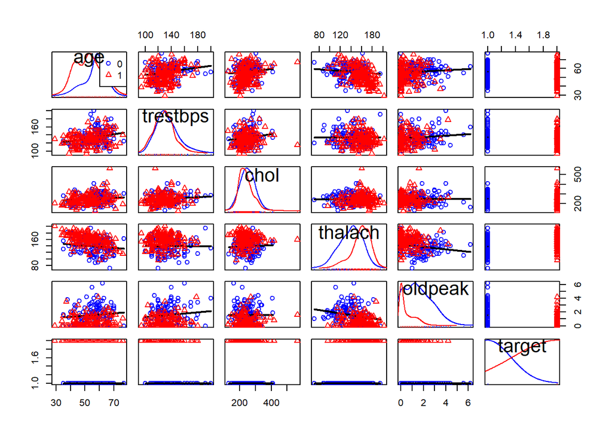

## Let’s try to do some PCA:

Looking at these plots, there does not seem to be much correlation between the continuous variables. The heatmap below seems to confirm this.

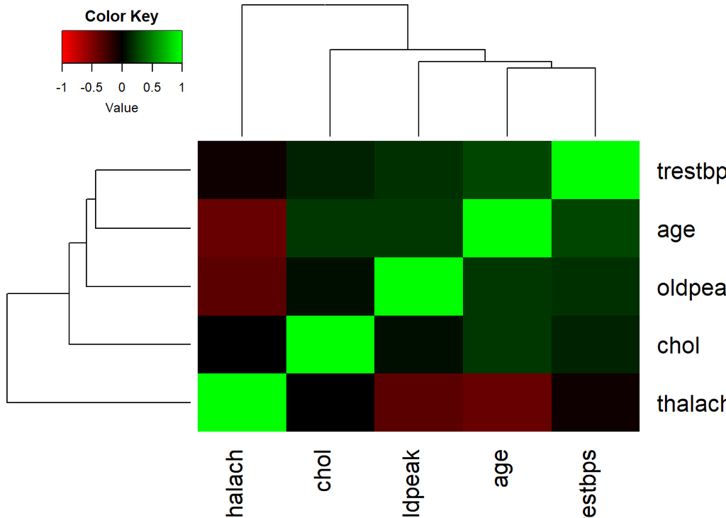

```
##                 age   trestbps        chol    thalach   oldpeak
## age       82.484558  44.495902  100.585076 -82.903318  2.214583
## trestbps  44.495902 307.586453  111.967215 -18.759131  3.934486
## chol     100.585076 111.967215 2686.426748 -11.800494  3.246794
## thalach  -82.903318 -18.759131  -11.800494 524.646406 -9.153518
## oldpeak    2.214583   3.934486    3.246794  -9.153518  1.348095
```

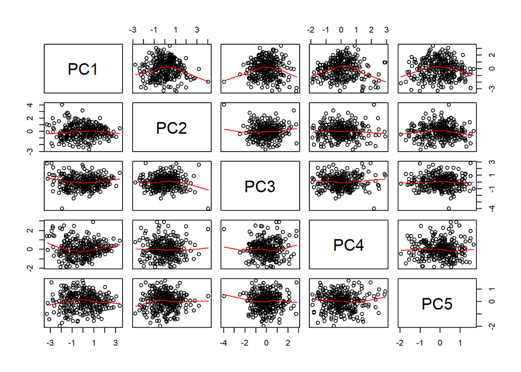

```
##     PC1 PC2 PC3 PC4 PC5
## PC1   1   0   0   0   0
## PC2   0   1   0   0   0
## PC3   0   0   1   0   0
## PC4   0   0   0   1   0
## PC5   0   0   0   0   1
```

There do not seem to be any correlations in the Principal Components. Let’s try to produce the Scree / Cumulative Proportion Plots:

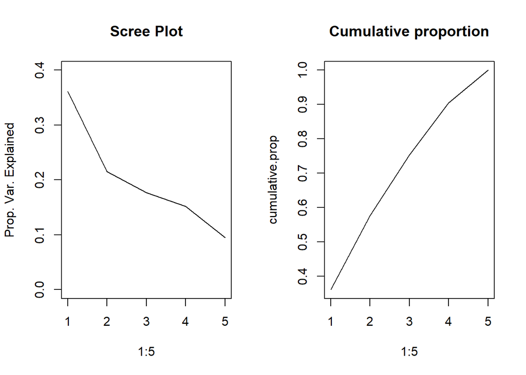

It looks like from the above plot, that 90.53% of the variability can be explained using 4 principal components. It does appear, though that all 5 continue to contribute to the model which is consistent with our earlier assessment that there is not significant correlation among the predictors.

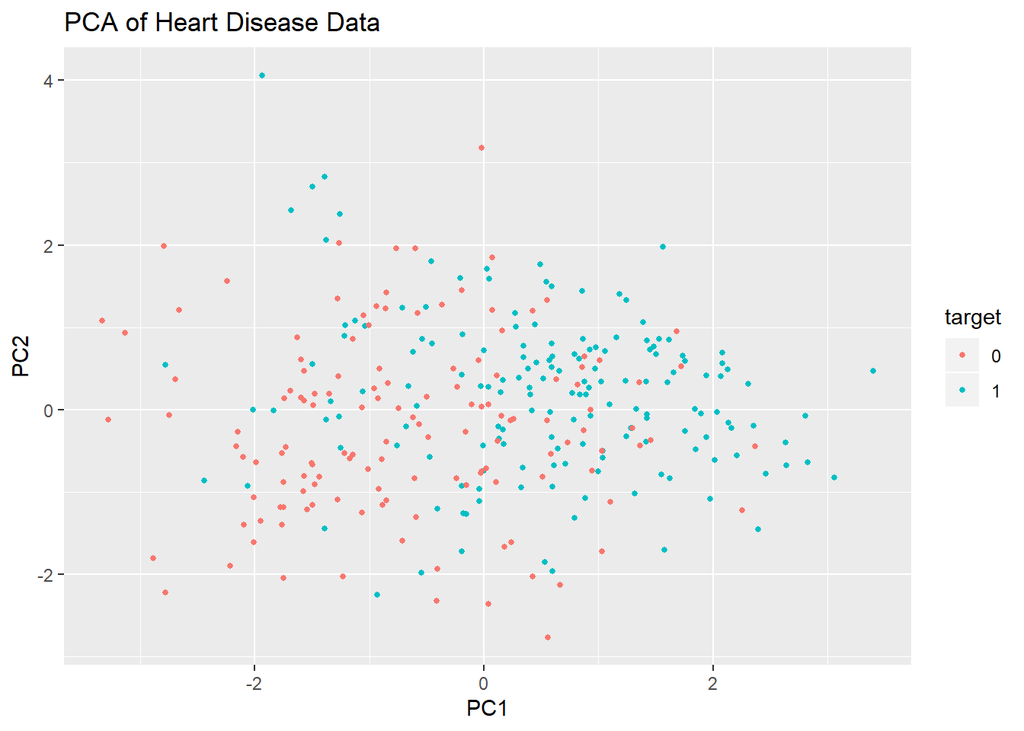

This pairs plot explores the correlation between the continuous predictors grouped by the outcome:

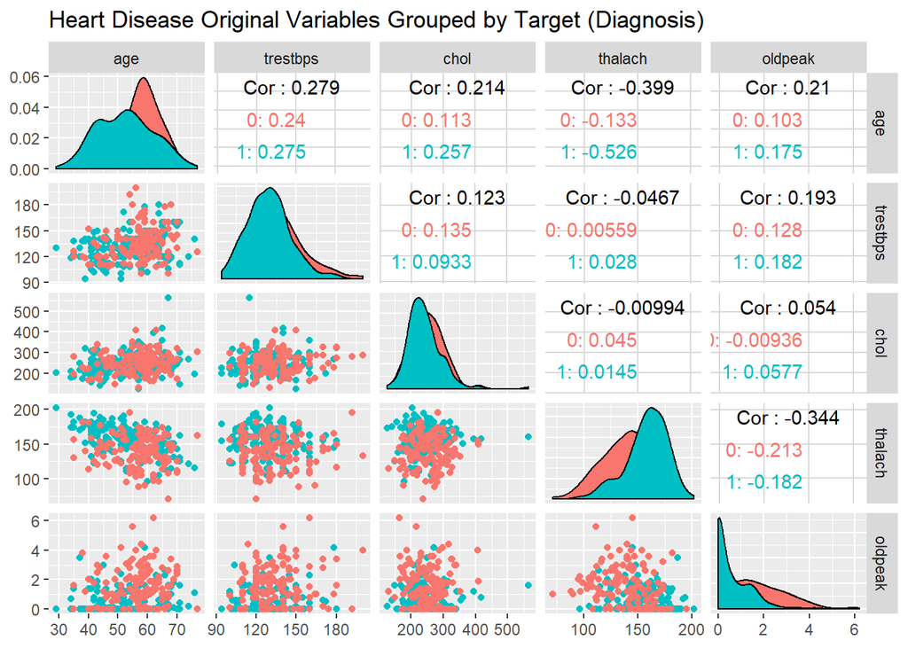

While this pairs plot explores the correlation between the Principal Components grouped by the outcome.

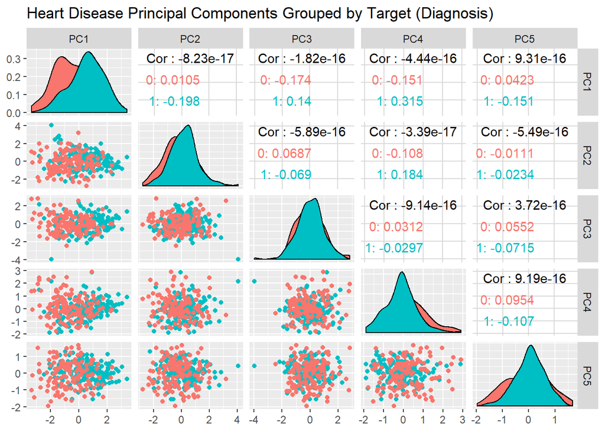

Running a number of PCA charts coded by response does not appear to show a clean discriminant that we can use to do regression on the Principal Components. Principal component 1 (PC1) does show some ability to distinguish against PC2, but there is still significant overlap. This indicates that these 5 continuous predictors may not perform well in a classfication model. Additional continuous predictors may help improve the performance of our model. The categorical predictors might have greater influence to differentiate with interaction terms.

Looking at the weighting on the principal components:

```
##                 PC1        PC2        PC3        PC4        PC5
## age      -0.5673990  0.1084469 -0.1783796 -0.5199937  0.6033944
## trestbps -0.3758463  0.4231668  0.7394680 -0.1439024 -0.3348860
## chol     -0.2453800  0.6922836 -0.5317555  0.3781374 -0.1864944
## thalach   0.5056805  0.4824636  0.2983680  0.1733984  0.6264389
## oldpeak  -0.4699721 -0.3116750  0.2226667  0.7320135  0.3107422
```

In looking at this table, we can see that each variable contributes a significant amount in at least one of the Principal Components. This is a good indication that the variables are not correlated with each other and that each might contribute something unique to our model. * PC1 seems to be a contrast between age and thalach. * PC2 seems to be largely influenced by chol, thalach, and trestbps. * PC3 seems to be a contrast between trestbps and chol. * PC4 seems to be a contrast between age and oldpeak. * PC5 seems to be largely influenced by age and thalach.

# Prep for Analysis

I considered doing a Train / Test split on the data, but think that we might try to do a k-fold cross validation of the model. In order to do that, we have to train the model first.

```r
library(caret)

levels(heart$target) = c("No","Yes")
#define the training control method for the model -- This is the cross validation.
train_control = trainControl(method = "cv", number = 10, classProbs = TRUE, savePredictions = TRUE, summaryFunction = twoClassSummary)

#fit the simple model using all the variables
simple_model = train(target~., data = heart, trControl = train_control, method = "glm", metric = "ROC", family = "binomial")
```

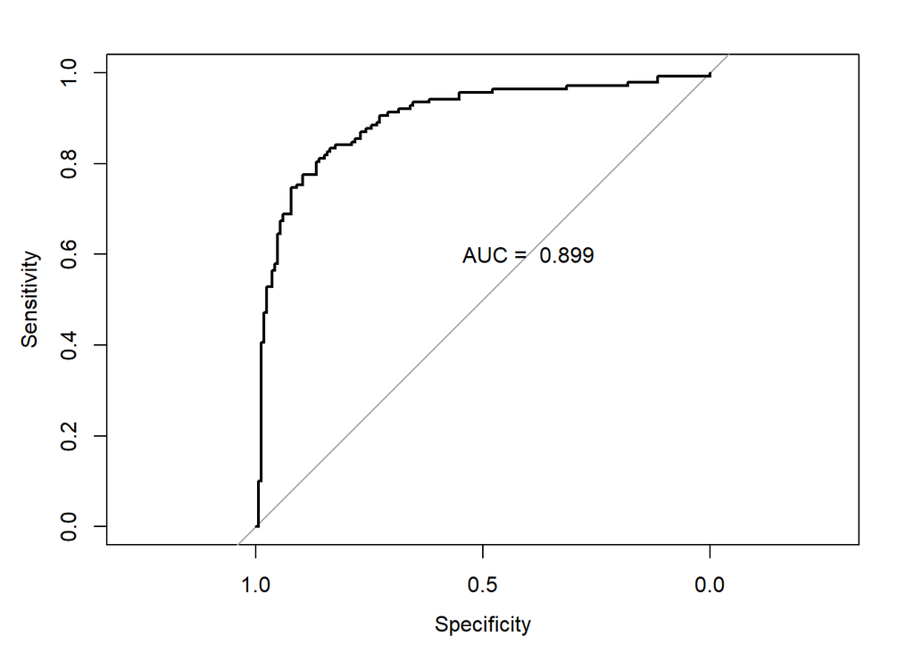

```r
#plot the ROC curve
testroc = roc(predictor = simple_model$pred$Yes, response = simple_model$pred$obs, levels = rev(levels(simple_model$pred$obs)))

plot(testroc, type = "S")
text(x = .40, y = .6,paste("AUC = ", round(testroc$auc, 3)))
```

and the coefficients:

```
##
## Call:  NULL
##
## Coefficients:
## (Intercept)          age         sex1          cp1          cp2
##    0.179045     0.027819    -1.862297     0.864708     2.003186
##         cp3     trestbps         chol         fbs1     restecg1
##    2.417107    -0.026162    -0.004291     0.445666     0.460582
##    restecg2      thalach       exang1      oldpeak       slope1
##   -0.714204     0.020055    -0.779111    -0.397174    -0.775084
##      slope2          ca1          ca2          ca3          ca4
##    0.689965    -2.342301    -3.483178    -2.247144     1.267961
##       thal1        thal2        thal3
##    2.637558     2.367747     0.915115
##
## Degrees of Freedom: 302 Total (i.e. Null);  280 Residual
## Null Deviance:       417.6
## Residual Deviance: 179.6     AIC: 225.6
```

Run the Hosmer / Lemeshow GOF test on the simple model:

```r
library(generalhoslem)
logitgof(heart$target, fitted(simple_model))
```

```
##
##  Hosmer and Lemeshow test (binary model)
##
## data:  heart$target, fitted(simple_model)
## X-squared = 17.259, df = 8, p-value = 0.02752
```

Get the odds ratio and confidence intervals for the simple model

```r
#odds ratio and confidence interval for the odds ratio
exp(cbind("Odds ratio" = coef(simple_model$finalModel), confint.default(simple_model$finalModel, level = 0.95)))
```

```
##              Odds ratio        2.5 %       97.5 %
## (Intercept)  1.19607455 0.0008388783 1705.3657507
## age          1.02820928 0.9782223176    1.0807506
## sex1         0.15531539 0.0507353858    0.4754644
## cp1          2.37431326 0.7647916762    7.3711098
## cp2          7.41263168 2.6265371216   20.9199817
## cp3         11.21337763 2.7385264219   45.9151451
## trestbps     0.97417703 0.9516385785    0.9972493
## chol         0.99571831 0.9874692001    1.0040363
## fbs1         1.56153000 0.4932455448    4.9435336
## restecg1     1.58499687 0.7242279606    3.4688181
## restecg2     0.48958146 0.0021525631  111.3509806
## thalach      1.02025748 0.9968164062    1.0442498
## exang1       0.45881379 0.1892476391    1.1123525
## oldpeak      0.67221672 0.4180461014    1.0809222
## slope1       0.46066516 0.0820175227    2.5874031
## slope2       1.99364591 0.3111720537   12.7730751
## ca1          0.09610620 0.0341833055    0.2702021
## ca2          0.03070966 0.0062575727    0.1507107
## ca3          0.10570072 0.0168254452    0.6640325
## ca4          3.55359909 0.1220646356  103.4539318
## thal1       13.97902426 0.0725453651 2693.6678725
## thal2       10.67331618 0.0658332335 1730.4281167
## thal3        2.49706223 0.0152750231  408.2036244
```

```r
#Variance Inflation Factor (VIF)
vif(simple_model$finalModel)
```

```
##       age      sex1       cp1       cp2       cp3  trestbps      chol
##  1.490855  1.696194  1.319692  1.498042  1.535883  1.273711  1.246004
##      fbs1  restecg1  restecg2   thalach    exang1   oldpeak    slope1
##  1.192707  1.113873  1.043845  1.532520  1.179411  1.602830  5.399716
##    slope2       ca1       ca2       ca3       ca4     thal1     thal2
##  6.225238  1.401724  1.477362  1.179712  1.115579 14.333837 46.911936
##     thal3
## 45.037963
```

# Stepwise Feature Selection (AIC-based):

[output not shown]

[output cut: 2562 more lines]

```
##            Df Deviance    AIC
## <none>          186.97 214.97
## - cp1       1   190.73 216.73
## - exang1    1   190.84 216.84
## - trestbps  1   191.16 217.16
## - thal1     1   191.19 217.19
## - ca3       1   195.35 221.35
## - oldpeak   1   195.68 221.68
## - sex1      1   196.82 222.82
## - thal2     1   198.76 224.76
## - slope1    1   198.81 224.81
## - cp3       1   201.83 227.83
## - ca2       1   207.39 233.39
## - cp2       1   207.78 233.78
## - ca1       1   212.80 238.80
```

```
## (Intercept)        sex1         cp1         cp2         cp3    trestbps
##   4.7866071  -1.5568056   1.0594885   2.2009453   2.5096018  -0.0217461
##      exang1     oldpeak      slope1         ca1         ca2         ca3
##  -0.8546017  -0.5706262  -1.4128266  -2.3425570  -3.0058612  -2.2472254
##       thal1       thal2
##   1.6032200   1.4359133
```

```
##   parameter       ROC      Sens      Spec      ROCSD    SensSD     SpecSD
## 1      none 0.9088882 0.7736264 0.8911765 0.03266442 0.1160311 0.06819278
```

```
##
##  Hosmer and Lemeshow test (binary model)
##
## data:  heart$target, fitted(simple_model_stepwise)
## X-squared = 15.124, df = 8, p-value = 0.05679
```

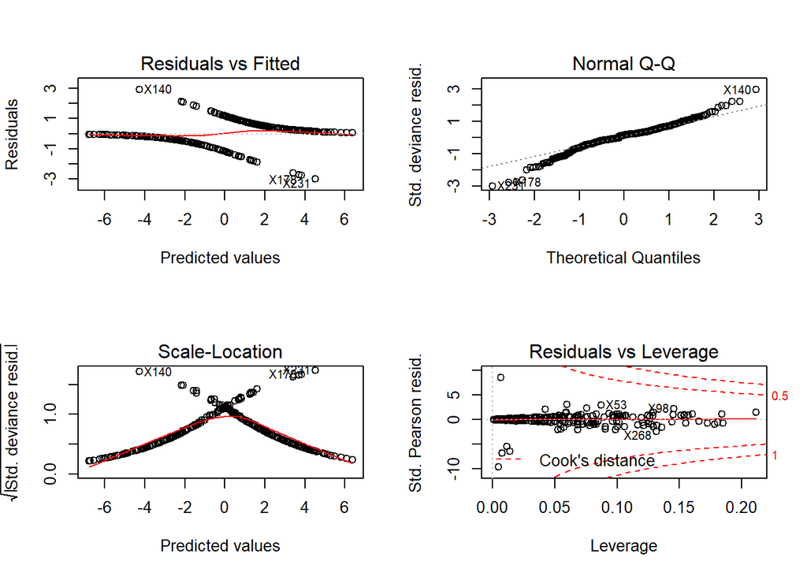

```
##               Odds ratio      2.5 %       97.5 %
## (Intercept) 119.89389472 4.65057298 3090.9193432
## sex1          0.21080840 0.07643846    0.5813851
## cp1           2.88489489 0.96144341    8.6563790
## cp2           9.03354886 3.29864930   24.7389151
## cp3          12.30003120 3.15530430   47.9480752
## trestbps      0.97848864 0.95785226    0.9995696
## exang1        0.42545261 0.18187652    0.9952353
## oldpeak       0.56517139 0.37692360    0.8474362
## slope1        0.24345417 0.10633581    0.5573845
## ca1           0.09608165 0.03646763    0.2531473
## ca2           0.04949611 0.01167018    0.2099251
## ca3           0.10569207 0.01843126    0.6060797
## thal1         4.96900701 1.11561514   22.1322119
## thal2         4.20348236 1.82538411    9.6797512
```

```
##     sex1      cp1      cp2      cp3 trestbps   exang1  oldpeak   slope1
## 1.441646 1.269872 1.418846 1.469118 1.125912 1.159451 1.253301 1.292847
##      ca1      ca2      ca3    thal1    thal2
## 1.262057 1.286514 1.048802 1.220232 1.310881
```

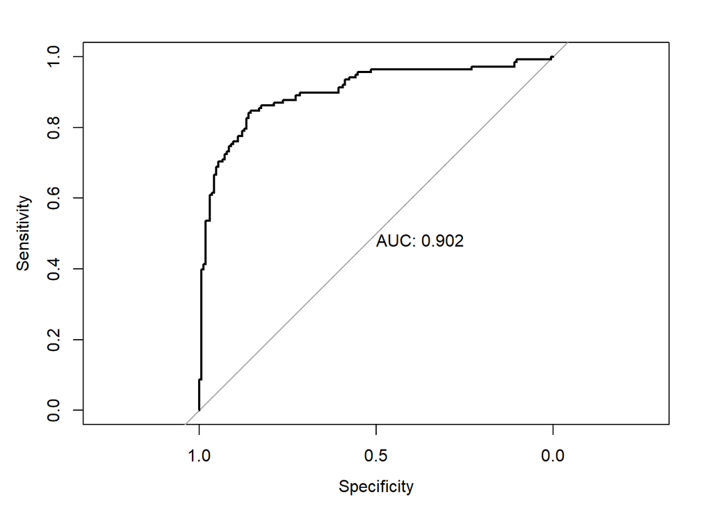

# Decision Tree on Simple Stepwise Model:

```r
# Training (66%) /Test (33%) Split
set.seed(777)
heart.train <- sample(1:nrow(heart), 202)
heart.test <- heart[-heart.train,]
# Independent response to compare prediction performance on test set
response.test <- target[-heart.train]

# Decision Tree based off Stepwise Feature Selection of Logistic Regression Model
heart.tree <- tree(target ~ thal + ca + cp + sex + trestbps + exang + oldpeak + slope, data = heart, subset = heart.train)
summary(heart.tree)
```

```
##
## Classification tree:
## tree(formula = target ~ thal + ca + cp + sex + trestbps + exang +
##     oldpeak + slope, data = heart, subset = heart.train)
## Variables actually used in tree construction:
## [1] "thal"    "cp"      "oldpeak" "ca"      "exang"   "sex"
## Number of terminal nodes:  13
## Residual mean deviance:  0.6038 = 114.1 / 189
## Misclassification error rate: 0.1287 = 26 / 202
```

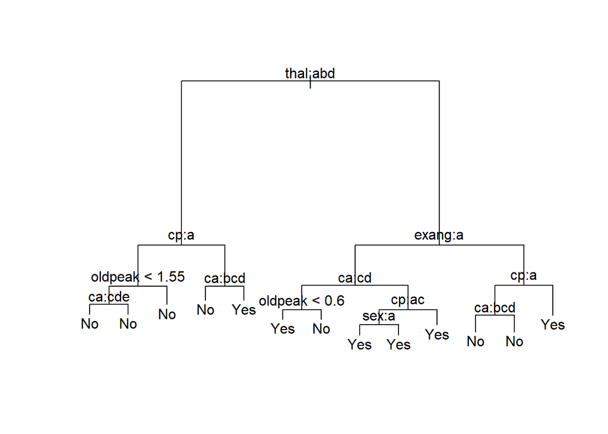

```r
plot(heart.tree)
text(heart.tree)
```

```r
# Cross-validate to determine optimal Pruned Tree
cv.heart <- cv.tree(heart.tree,FUN=prune.misclass)
cv.heart
```

```
## $size
## [1] 13  8  6  4  2  1
##
## $dev
## [1] 43 42 47 51 48 88
##
## $k
## [1] -Inf  0.0  1.5  3.0  4.0 45.0
##
## $method
## [1] "misclass"
##
## attr(,"class")
## [1] "prune"         "tree.sequence"
```

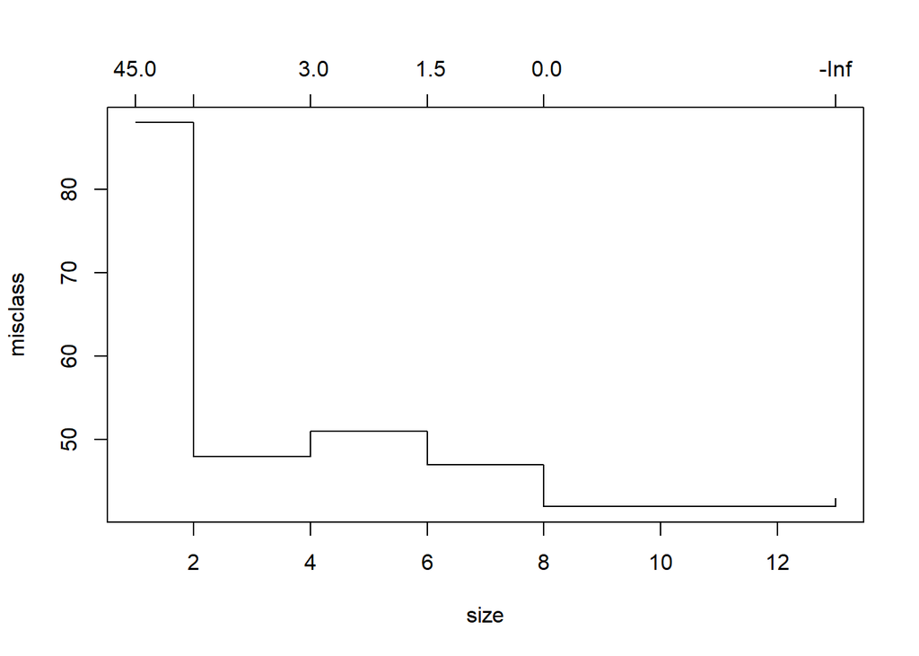

```r
# Smallest Misclassifcation Rate from size 8-13
plot(cv.heart)
```

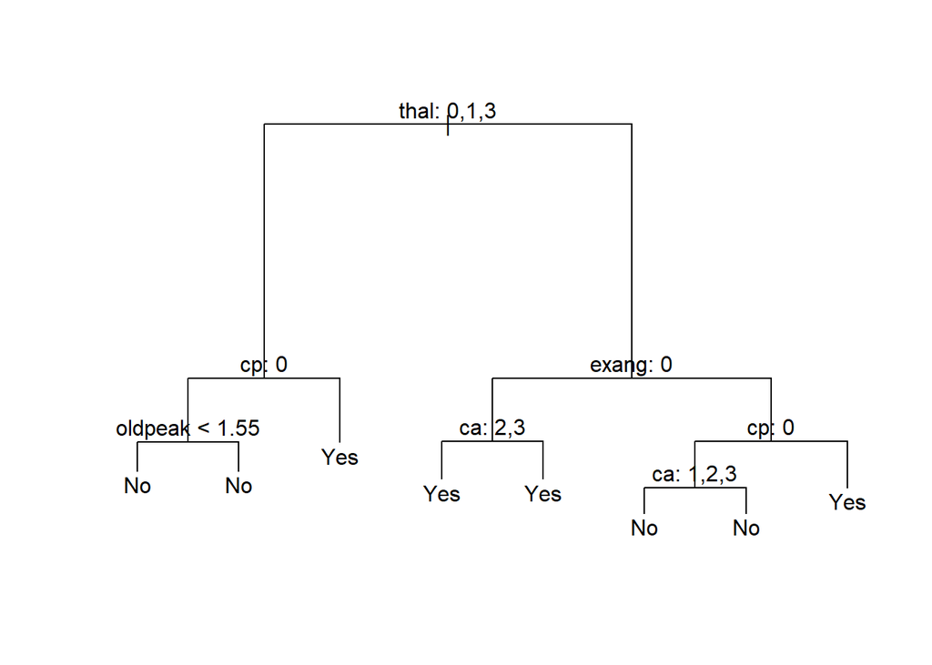

```r
# Prune Tree to Optimized Number of Nodes (8)
prune.heart <- prune.tree(heart.tree, best=8)
plot(prune.heart)
text(prune.heart,pretty=0)
```

```r
# Predict on Test Set
heart.tree_pred <- predict(prune.heart, heart.test, type="class")
table(heart.tree_pred, response.test)
```

```
##                response.test
## heart.tree_pred  0  1
##             No  38 12
##             Yes 12 39
```

```r
# Performance Metrics
TN <- 38
TP <- 39
FN <- 12
FP <- 12
Total <- TN + TP + FN + FP
## Accuracy
acc <- (TP+TN)/Total
acc
```

```
## [1] 0.7623762
```

```r
## Sensitivity
sen <- TP/(TP+FN)
sen
```

```
## [1] 0.7647059
```

```r
## Specificity
spe <- TN/(TN+FP)
spe
```

```
## [1] 0.76
```

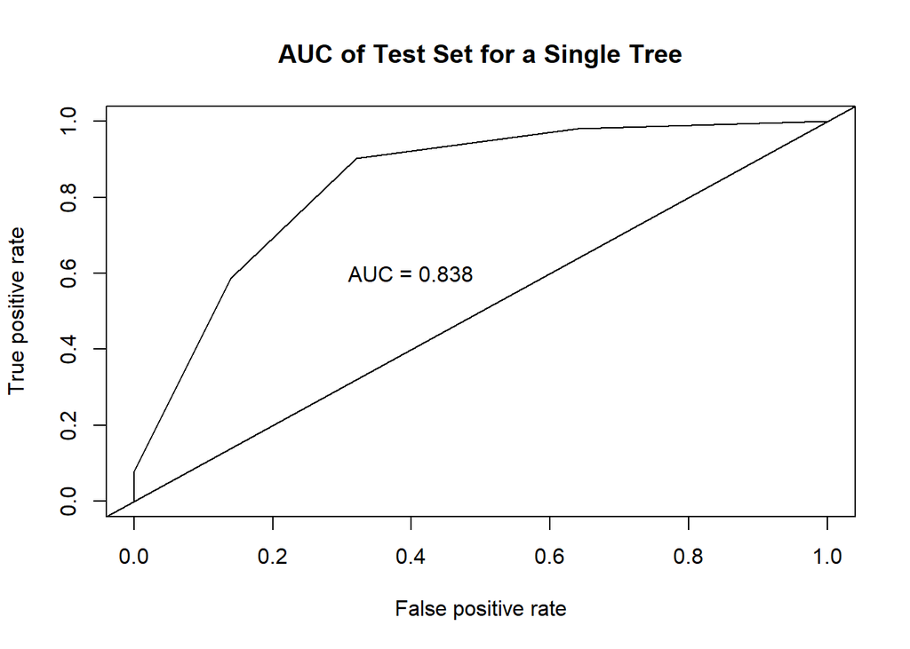

```r
# ROC Curve for Single Tree
tree.pred <- predict(prune.heart,heart.test,type="vector")

pred <- prediction(tree.pred[,2], heart.test$target)
roc.perf <-  performance(pred, measure = "tpr", x.measure = "fpr")
auc <- performance(pred, measure = "auc")
auc <- auc@y.values
plot(roc.perf, main= "AUC of Test Set for a Single Tree")
abline(a=0, b= 1)
text(x = .40, y = .6, paste("AUC = ", round(auc[[1]],3), sep = ""))
```